# Homework Assignment #2: Regression Assumptions, Analytic Strategies, Polynominal Regression, & Interactions Among Continuous Variables

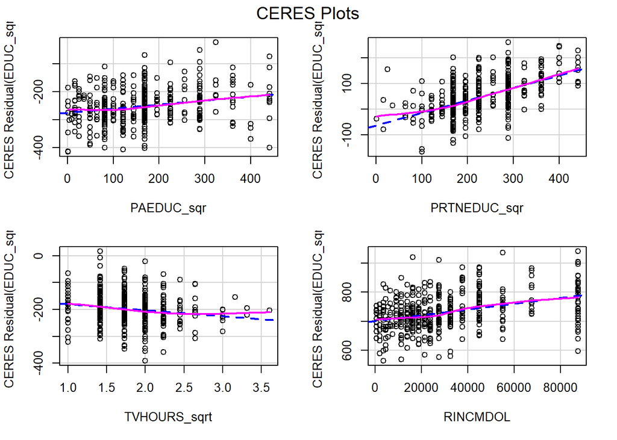

```r
#Linearity
newdf.lm.2d <- lm(EDUC_sqr ~ PAEDUC_sqr + PRTNEDUC_sqr + TVHOURS_sqrt + RINCMDOL, data = new_df)
ceresPlots(newdf.lm.2d)
```

```r
#linearity statistical assessment
resettest(newdf.lm.2d, power=2:3, type="regressor")
```

```
##
##  RESET test
##
## data:  newdf.lm.2d
## RESET = 2.0397, df1 = 8, df2 = 429, p-value = 0.0406
```

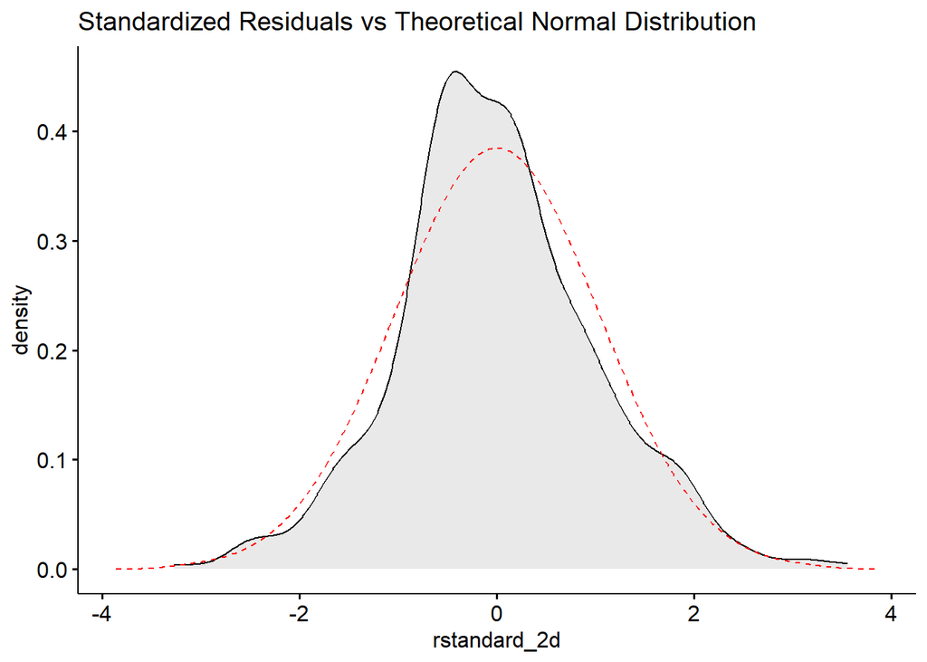

```r
#Normality
ggdensity(new_df,
          x = "rstandard_2d",
          fill = "lightgray",
          title = "Standardized Residuals vs Theoretical Normal Distribution") +
  stat_overlay_normal_density(color = "red",
                              linetype = "dashed")
```

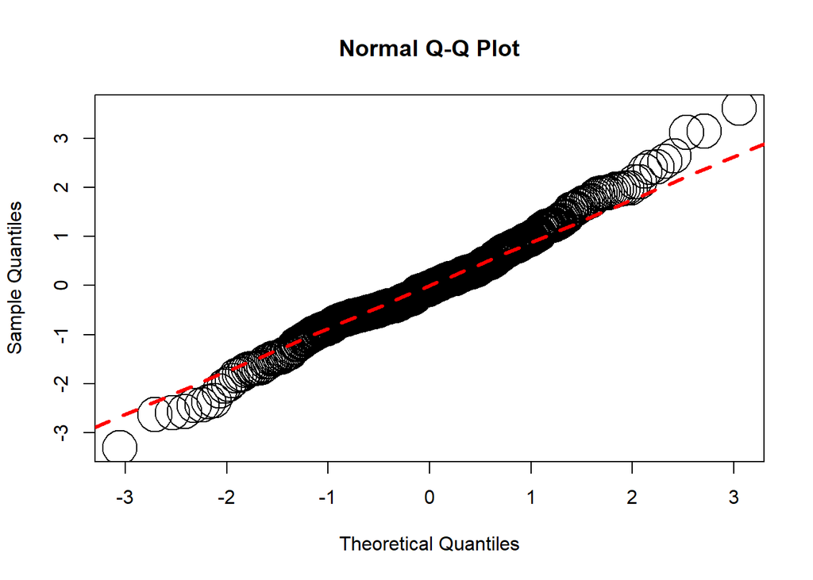

```r
qqnorm(new_df$rstudent_2d, cex = 4)
qqline(new_df$rstudent_2d, lty = 2, col = "red", lwd = 3)
```

```r
shapiro.test(new_df$rstudent_2d)
```

```
##
##  Shapiro-Wilk normality test
##
## data:  new_df$rstudent_2d
## W = 0.98939, p-value = 0.002747
```

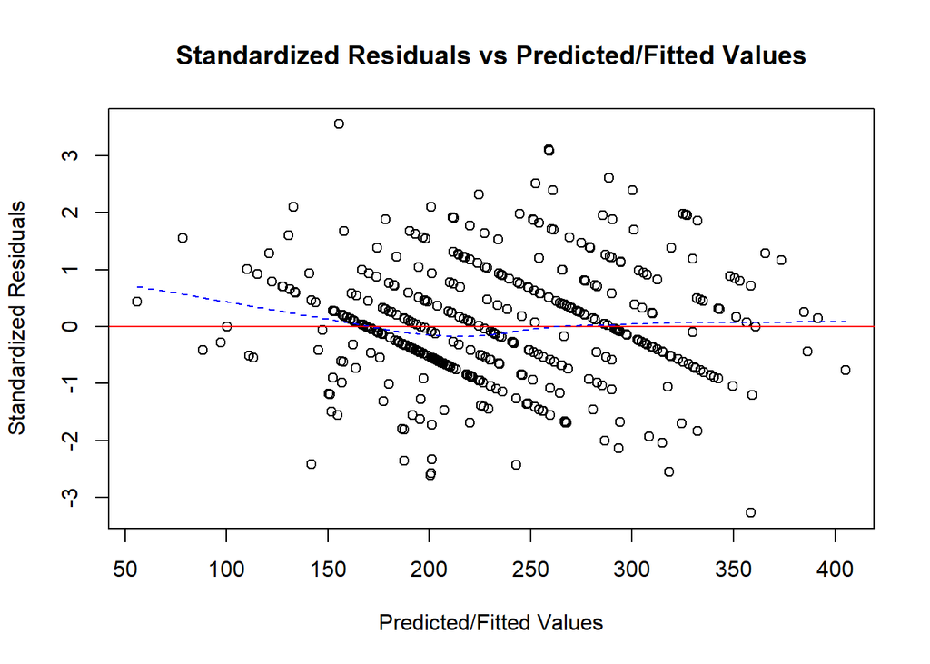

```r
#Homoscedasticity
plot(new_df$rstandard_2d ~ new_df$predicted_2d,
     main = "Standardized Residuals vs Predicted/Fitted Values",
     xlab = "Predicted/Fitted Values",
     ylab = "Standardized Residuals",
     cex = 1,
     col = "black")
abline(lm(new_df$rstandard_2d ~ new_df$predicted_2d),
       col = "red")
lines(lowess(new_df$rstandard_2d ~ new_df$predicted_2d),
      col = "blue", lty = 2)
```

```r
bptest(newdf.lm.2d)
```

```
##
##  studentized Breusch-Pagan test
##
## data:  newdf.lm.2d
## BP = 16.61, df = 4, p-value = 0.002301
```

7.6. Report on what assumption violations remain at this point. Do not make any further effort beyond this point to transform data to meet regression assumptions.

**Answer:**

After transforming the data, we can see from the graphs and statistical analysis that, normality, linearity and homoscedasticity assumption violations still exist.

8. Create a scatterplot of observed versus predicted `educ` for your final model (`plot()`). Fit a regression line to this plot and make an interpretation of the plot.

```r
newdf.lm.2d <- summary(newdf.lm.2d)$r.squared
newdf.lm.2d
```

```
## [1] 0.5152554
```

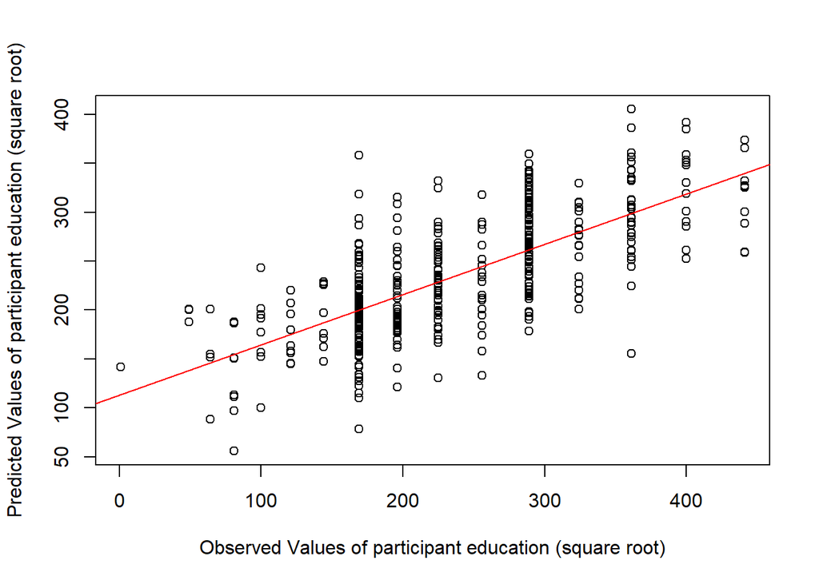

```r
plot(predicted_2d ~ EDUC_sqr, data = new_df,
     ylab = "Predicted Values of participant education (square root)",
     xlab = "Observed Values of participant education (square root)")
abline(lm(predicted_2d ~ EDUC_sqr, data = new_df),
       col = "red")
mylabel = bquote(italic(R)^2 == .(format(newdf.lm.2d, digits = 2)))
text(3, 8, labels = mylabel)
```

The scatter plot gives us somewhat a positive relationship, but line is not perfectly aligned with the observed values. There are error in observation. The model is not accurately capturing the relationship between the independent and dependent variables. This can be caused by a number of factors, such as missing variables, assumption violations. There exist a few outliers which indicates that the model is not capturing some important aspect of the relationship between the independent and dependent variables. They can also indicate errors or problems in the data.

9. Create a table summarizing these results as described in the previous exercise.

```r
gss.lm.1 <- lm(EDUC ~ PAEDUC + PRTNEDUC + TVHOURS + RINCMDOL, data = gss)
summary(gss.lm.1)
```

```
##
## Call:
## lm(formula = EDUC ~ PAEDUC + PRTNEDUC + TVHOURS + RINCMDOL, data = gss)
##
## Residuals:
##      Min       1Q   Median       3Q      Max
## -10.1912  -1.1609   0.0111   1.1651   7.6752
##
## Coefficients:
##               Estimate Std. Error t value Pr(>|t|)
## (Intercept)  6.131e+00  5.615e-01  10.920  < 2e-16 ***
## PAEDUC       1.239e-01  2.622e-02   4.724 3.12e-06 ***
## PRTNEDUC     4.385e-01  4.031e-02  10.878  < 2e-16 ***
## TVHOURS     -1.909e-01  6.232e-02  -3.064  0.00232 **
## RINCMDOL     3.225e-05  4.511e-06   7.150 3.67e-12 ***
## ---
## Signif. codes:  0 '***' 0.001 '**' 0.01 '*' 0.05 '.' 0.1 ' ' 1
##
## Residual standard error: 2.058 on 437 degrees of freedom
## Multiple R-squared:  0.4837, Adjusted R-squared:  0.479
## F-statistic: 102.3 on 4 and 437 DF,  p-value: < 2.2e-16
```

```r
newdf.lm.2d <- lm(EDUC_sqr ~ PAEDUC_sqr + PRTNEDUC_sqr + TVHOURS_sqrt + RINCMDOL, data = new_df)
summary(newdf.lm.2d)
```

```
##
## Call:
## lm(formula = EDUC_sqr ~ PAEDUC_sqr + PRTNEDUC_sqr + TVHOURS_sqrt +
##     RINCMDOL, data = new_df)
##
## Residuals:
##      Min       1Q   Median       3Q      Max
## -189.485  -34.745   -3.549   34.487  205.623
##
## Coefficients:
##                Estimate Std. Error t value Pr(>|t|)
## (Intercept)   1.122e+02  1.710e+01   6.562 1.51e-10 ***
## PAEDUC_sqr    1.449e-01  3.093e-02   4.686 3.73e-06 ***
## PRTNEDUC_sqr  4.863e-01  3.918e-02  12.411  < 2e-16 ***
## TVHOURS_sqrt -2.274e+01  7.056e+00  -3.222  0.00137 **
## RINCMDOL      9.977e-04  1.291e-04   7.727 7.60e-14 ***
## ---
## Signif. codes:  0 '***' 0.001 '**' 0.01 '*' 0.05 '.' 0.1 ' ' 1
##
## Residual standard error: 58.94 on 437 degrees of freedom
## Multiple R-squared:  0.5153, Adjusted R-squared:  0.5108
## F-statistic: 116.1 on 4 and 437 DF,  p-value: < 2.2e-16
```

```r
apa.reg.table(newdf.lm.2d, table.number = 2)
```

```
##
##
## Table 2
##
## Regression results using EDUC_sqr as the criterion
##
##
##     Predictor        b        b_95%_CI  beta    beta_95%_CI sr2  sr2_95%_CI
##   (Intercept) 112.21** [78.60, 145.82]
##    PAEDUC_sqr   0.14**    [0.08, 0.21]  0.17   [0.10, 0.24] .02  [.00, .04]
##  PRTNEDUC_sqr   0.49**    [0.41, 0.56]  0.46   [0.39, 0.54] .17  [.12, .22]
##  TVHOURS_sqrt -22.74** [-36.61, -8.87] -0.11 [-0.18, -0.04] .01 [-.00, .03]
##      RINCMDOL   0.00**    [0.00, 0.00]  0.27   [0.20, 0.34] .07  [.03, .10]
##
##
##
##       r             Fit
##
##   .39**
##   .63**
##  -.31**
##   .46**
##             R2 = .515**
##         95% CI[.45,.56]
##
##
## Note. A significant b-weight indicates the beta-weight and semi-partial correlation are also significant.
## b represents unstandardized regression weights. beta indicates the standardized regression weights.
## sr2 represents the semi-partial correlation squared. r represents the zero-order correlation.
## Square brackets are used to enclose the lower and upper limits of a confidence interval.
## * indicates p < .05. ** indicates p < .01.
##
```

10. Write a brief summary of the results of this analysis and refer to the table in these results.  
    **Answer:**

51.5% of the variation in the dependent variable is explained by the independent variables in the final regression model whereas 47.9% of the variation in the dependent variable is explained by the independent variables in the first model.Hours of television is still a significant factor of participants education compared to other independent variables.

### Part III: Checking Assumptions & Transforming Data II

This set of exercises requires use of the `Prestige` data set from the `carData` package in R.

1. Perform a multiple regression of `prestige` on `education` and `income`.

```r
Prestige <- Prestige %>%
  drop_na()

prestige.lm.1<- lm(prestige ~ education + income, data = Prestige)
summary(prestige.lm.1)
```

```
##
## Call:
## lm(formula = prestige ~ education + income, data = Prestige)
##
## Residuals:
##      Min       1Q   Median       3Q      Max
## -16.9367  -4.8881   0.0116   4.9690  15.9280
##
## Coefficients:
##               Estimate Std. Error t value Pr(>|t|)
## (Intercept) -7.6210352  3.1162309  -2.446   0.0163 *
## education    4.2921076  0.3360645  12.772  < 2e-16 ***
## income       0.0012415  0.0002185   5.682 1.45e-07 ***
## ---
## Signif. codes:  0 '***' 0.001 '**' 0.01 '*' 0.05 '.' 0.1 ' ' 1
##
## Residual standard error: 7.45 on 95 degrees of freedom
## Multiple R-squared:  0.814,  Adjusted R-squared:  0.8101
## F-statistic: 207.9 on 2 and 95 DF,  p-value: < 2.2e-16
```

2. Conduct an evaluation of the assumptions for regression analysis.  
   2.1. Begin by running and presenting a `plot()` on the saved model object that is the result of this analysis (if you are using BlueSky, you can get these plots by checking this option when setting up in the analysis).

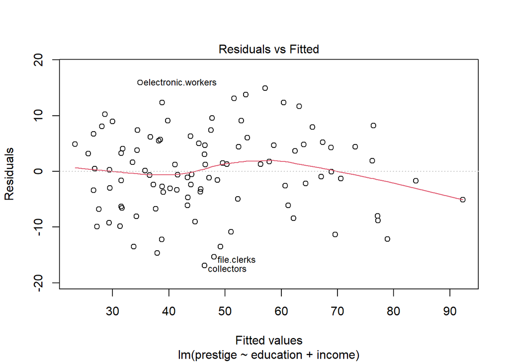

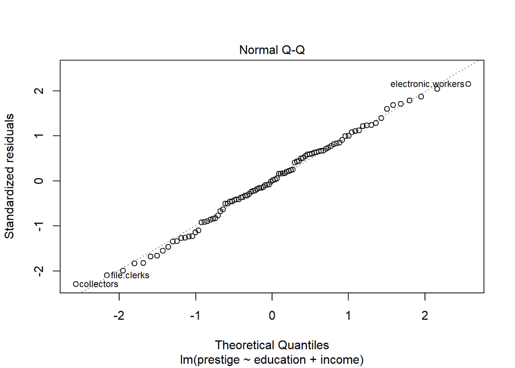

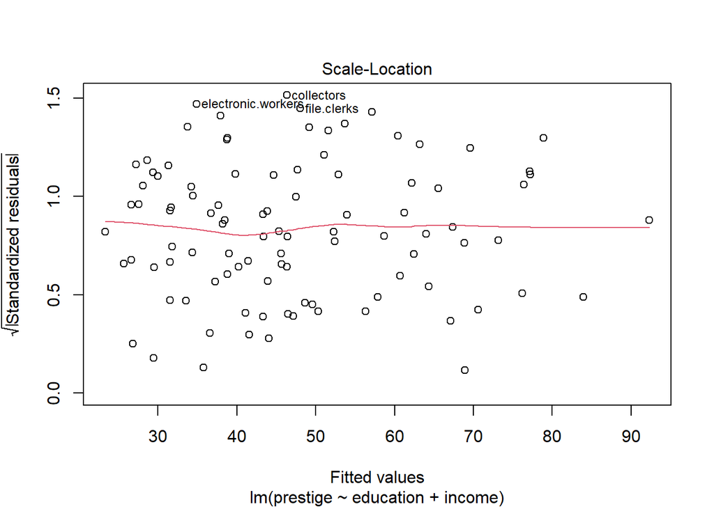

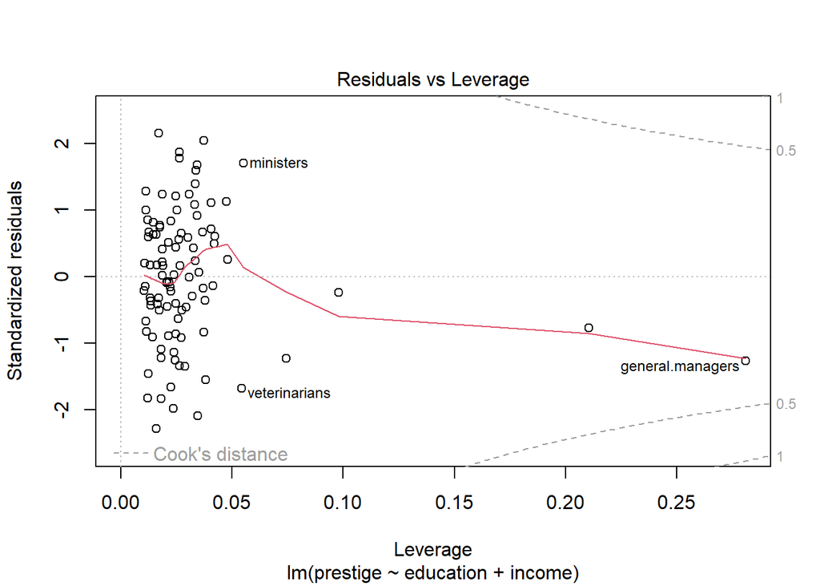

```r
plot(prestige.lm.1)
```

2.2. Present at least one additional plot and statistic for each assumption (except for correct model specification) discussed in class for this regression model and discuss whether any assumptions have been violated.  
**Independence Assumption:**

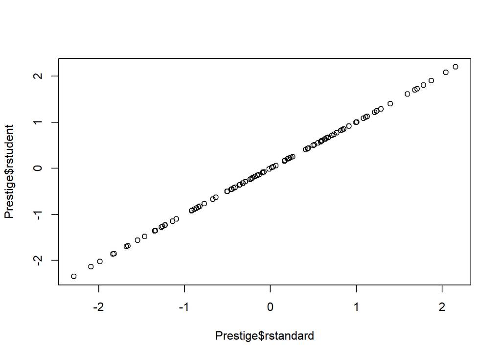

```r
Prestige$predicted <- fitted(prestige.lm.1)
Prestige$residuals <- residuals(prestige.lm.1)
Prestige$rstudent <- rstudent(prestige.lm.1)
Prestige$rstandard <- rstandard(prestige.lm.1)
plot(Prestige$rstandard, Prestige$rstudent)
```

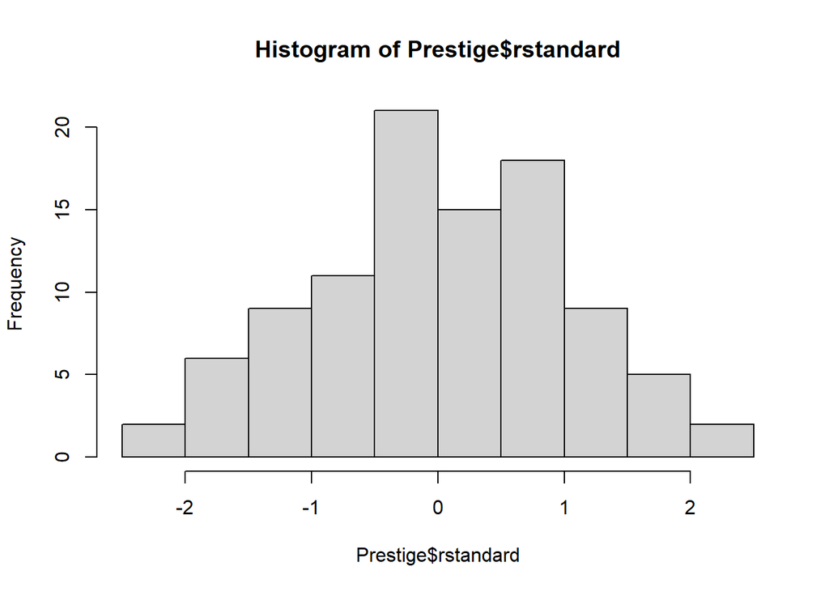

```r
hist(Prestige$rstandard)
```

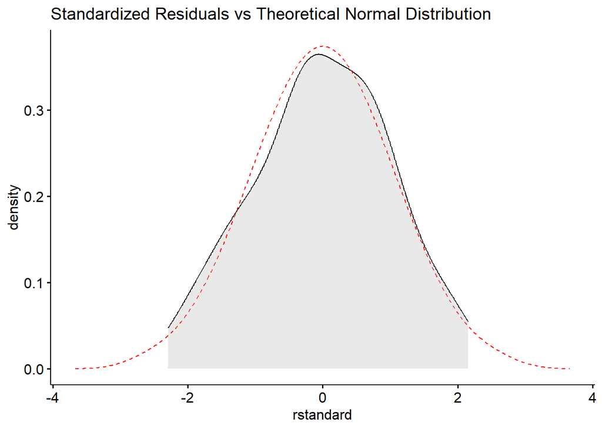

```r
ggdensity(Prestige,
          x = "rstandard",
          fill = "lightgray",
          title = "Standardized Residuals vs Theoretical Normal Distribution") +
  stat_overlay_normal_density(color = "red",
                              linetype = "dashed")
```

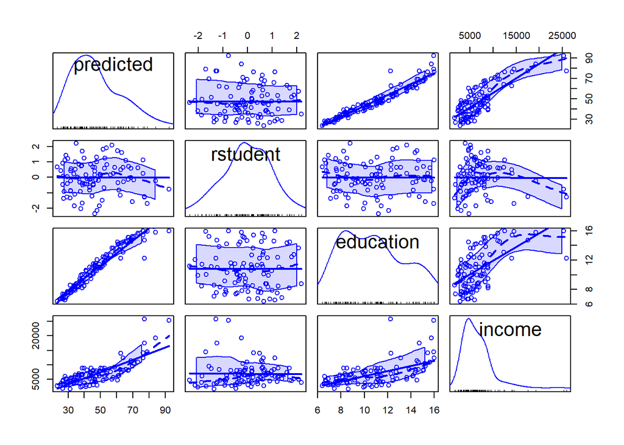

```r
scatterplotMatrix(~predicted + rstudent + education + income, data=Prestige)
```

```r
durbinWatsonTest(prestige.lm.1)
```

```
##  lag Autocorrelation D-W Statistic p-value
##    1       0.2029051      1.589283   0.036
##  Alternative hypothesis: rho != 0
```

From the graph and the statistical test, it can be seen that there is a possibility of the violation of independence.

**Linearity Assumption:**

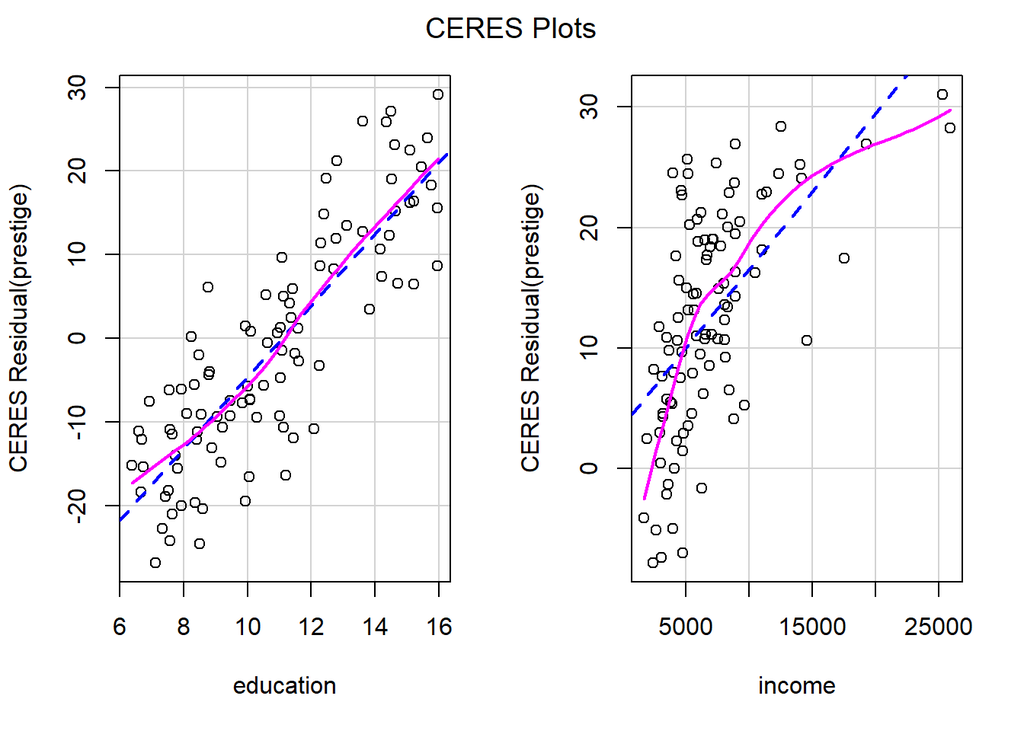

```r
ceresPlots(prestige.lm.1)
```

```r
resettest(prestige.lm.1, power=2:3, type="regressor")
```

```
##
##  RESET test
##
## data:  prestige.lm.1
## RESET = 5.4035, df1 = 4, df2 = 91, p-value = 0.0005986
```

From the graph and the statistical test, it can be seen that there is a possibility of the violation of linearity.

**Normality Assumption:**

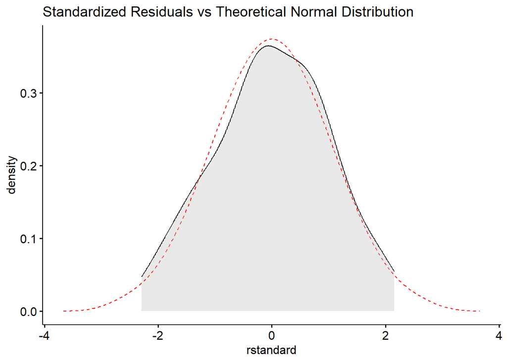

```r
ggdensity(Prestige,
          x = "rstandard",
          fill = "lightgray",
          title = "Standardized Residuals vs Theoretical Normal Distribution") +
  stat_overlay_normal_density(color = "red",
                              linetype = "dashed")
```

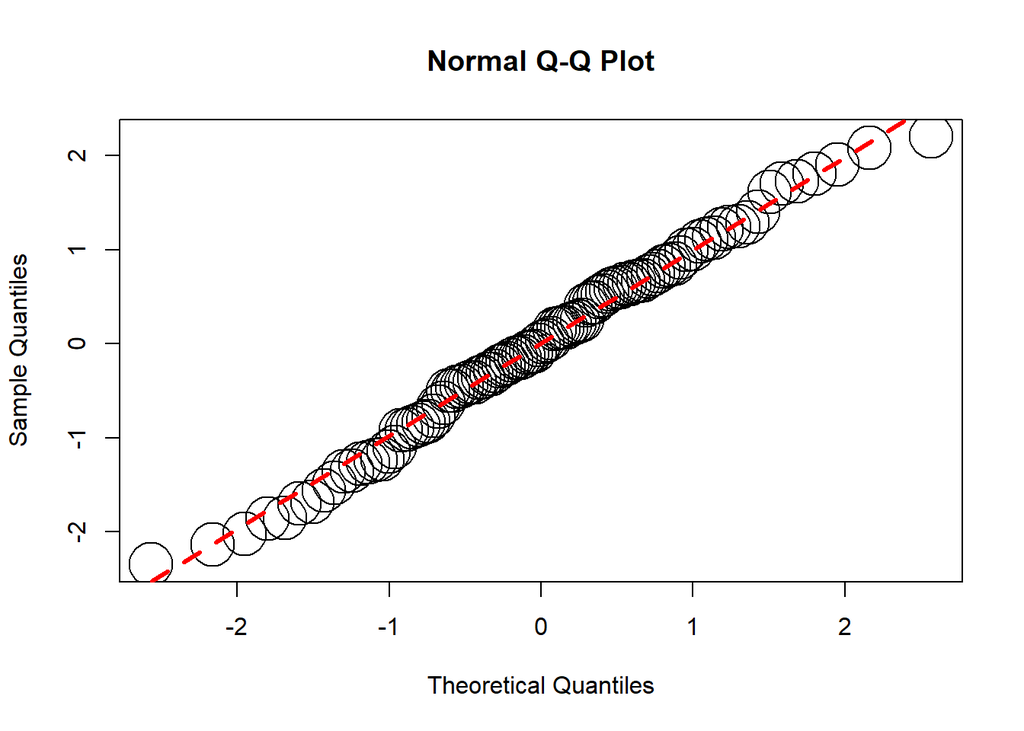

```r
qqnorm(rstudent(prestige.lm.1), cex = 4)
qqline(rstudent(prestige.lm.1), lty = 2, col = "red", lwd = 3)
```

```r
#normality statistical assessment
shapiro.test(Prestige$rstudent)
```

```
##
##  Shapiro-Wilk normality test
##
## data:  Prestige$rstudent
## W = 0.99097, p-value = 0.7546
```

From the graph and the statistical test, it can be seen that there is no violation of normality.

**Homoscedasticity Assumption:**

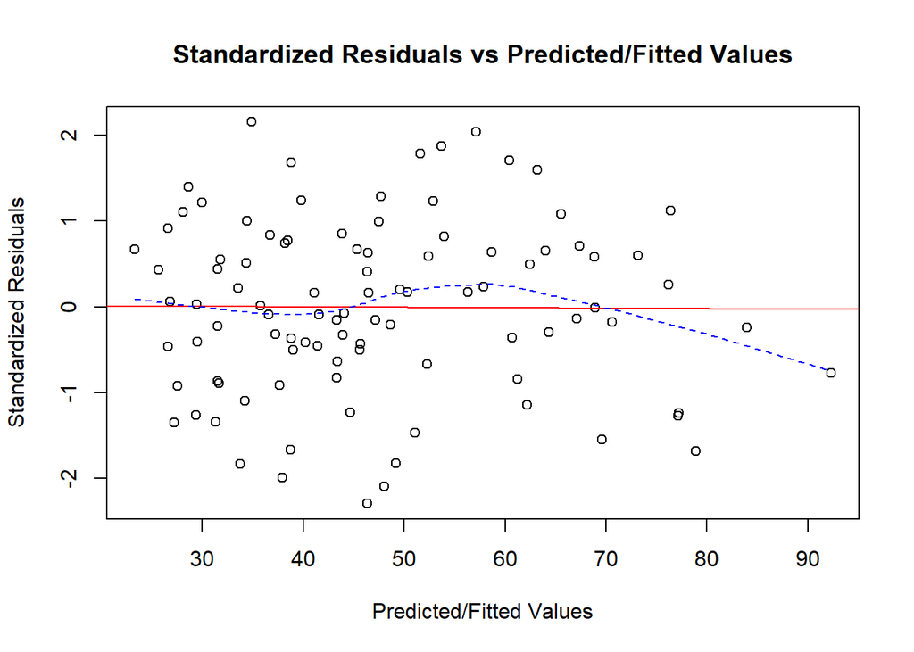

```r
plot(Prestige$rstandard ~ Prestige$predicted,
     main = "Standardized Residuals vs Predicted/Fitted Values",
     xlab = "Predicted/Fitted Values",
     ylab = "Standardized Residuals",
     cex = 1,
     col = "black")
abline(lm(Prestige$rstandard ~ Prestige$predicted),
       col = "red")
lines(lowess(Prestige$rstandard ~ Prestige$predicted),
      col = "blue", lty = 2)
```

```r
#homoscedasticity statistical assessment
bptest(prestige.lm.1)
```

```
##
##  studentized Breusch-Pagan test
##
## data:  prestige.lm.1
## BP = 4.6534, df = 2, p-value = 0.09762
```

From the graph and the statistical test, it can be seen that there is no violation of homoscedasticity.

2.3. Use the methods discussed in class to try and remedy any violations of assumptions, if necessary. Describe briefly what transformations were performed and why.

2.4. Then, re-run the regression analysis, if necessary, with any transformed data. If you do re-run the analysis with transformed data, re-run the assumption checks you did before to check for any violations of regression assumptions. Report your findings for each of the 4 assumptions (not including correct specification). You only need to make one attempt to fix the model, please don’t spend time trying to make it fit perfectly beyond this step.

**Answer of 2.3 and 2.4:** Independence and linearity assumptions were violated.

From the CERES plot, we can find the shape of the data of both independent variable. Based on that, we will perform log transformation on income variable and square transformation on education variable. These transformation are performed based on the ‘Bulging Rule’.

```r
Prestige$income_log <- log(Prestige$income)
prestige.lm.2 <- lm(prestige ~ education + income_log, data = Prestige)
summ(prestige.lm.2)
```

```
## MODEL INFO:
## Observations: 98
## Dependent Variable: prestige
## Type: OLS linear regression
##
## MODEL FIT:
## F(2,95) = 247.43, p = 0.00
## R² = 0.84
## Adj. R² = 0.84
##
## Standard errors: OLS
## ---------------------------------------------------
##                        Est.    S.E.   t val.      p
## ----------------- --------- ------- -------- ------
## (Intercept)         -101.19   12.85    -7.88   0.00
## education              4.04    0.32    12.73   0.00
## income_log            12.06    1.67     7.21   0.00
## ---------------------------------------------------
```

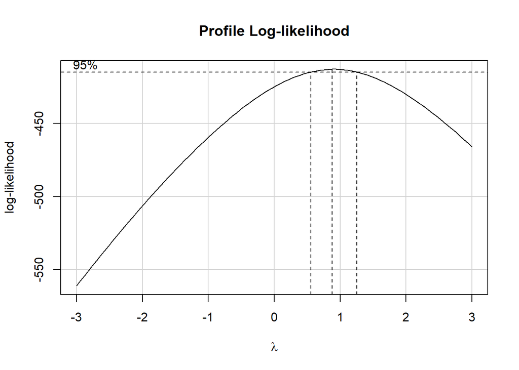

```r
bc_prestige.lm.2 <- boxCox(prestige.lm.2, seq(-3, 3), plotit = TRUE)
```

```r
lambda1 <- bc_prestige.lm.2$x[which.max(bc_prestige.lm.2$y)]
lambda1
```

```
## [1] 0.8787879
```

```r
Prestige$education_sqr<- (Prestige$education)^2
prestige.lm.3 <- lm(prestige ~ education_sqr + income_log, data = Prestige)
summ(prestige.lm.3)
```

```
## MODEL INFO:
## Observations: 98
## Dependent Variable: prestige
## Type: OLS linear regression
##
## MODEL FIT:
## F(2,95) = 250.93, p = 0.00
## R² = 0.84
## Adj. R² = 0.84
##
## Standard errors: OLS
## ----------------------------------------------------
##                         Est.    S.E.   t val.      p
## ------------------- -------- ------- -------- ------
## (Intercept)           -75.65   13.69    -5.53   0.00
## education_sqr           0.18    0.01    12.85   0.00
## income_log             11.54    1.68     6.85   0.00
## ----------------------------------------------------
```

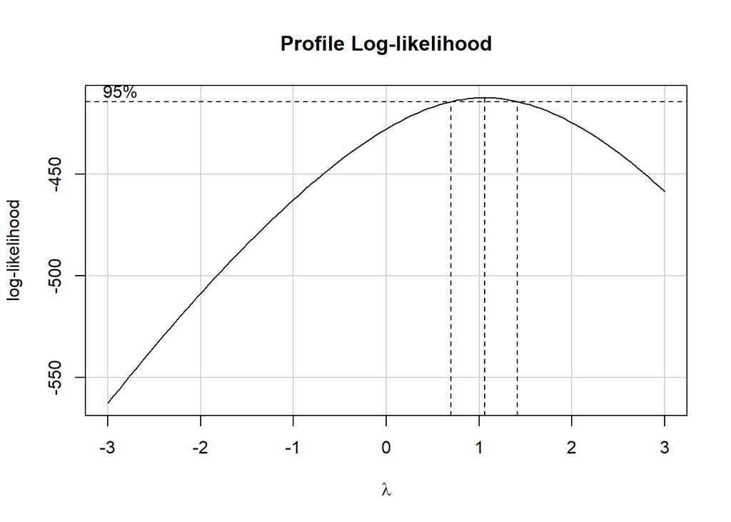

```r
bc_prestige.lm.3 <- boxCox(prestige.lm.3, seq(-3, 3), plotit = TRUE)
```

```r
lambda2 <- bc_prestige.lm.3$x[which.max(bc_prestige.lm.3$y)]
lambda2
```

```
## [1] 1.060606
```

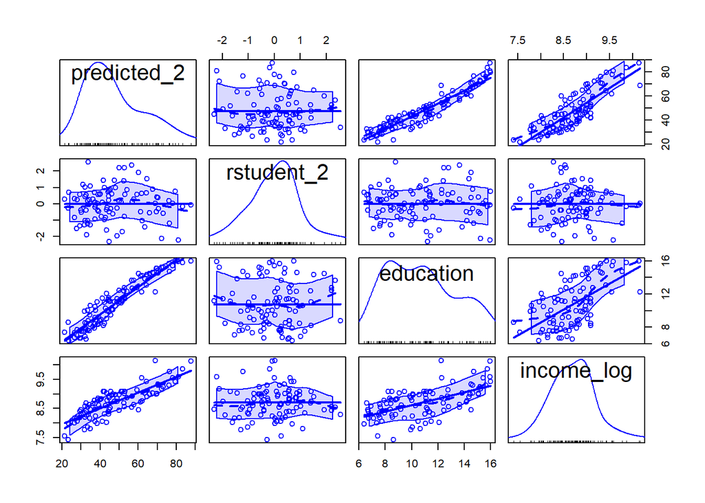

```r
Prestige$predicted_2 <- fitted(prestige.lm.3)
Prestige$residuals_2 <- residuals(prestige.lm.3)
Prestige$rstudent_2 <- rstudent(prestige.lm.3)
Prestige$rstandard_2 <- rstandard(prestige.lm.3)


#Independence
scatterplotMatrix(~predicted_2 + rstudent_2 + education + income_log, data=Prestige)
```

```r
durbinWatsonTest(prestige.lm.3)
```

```
##  lag Autocorrelation D-W Statistic p-value
##    1      0.04995196      1.893631   0.484
##  Alternative hypothesis: rho != 0
```

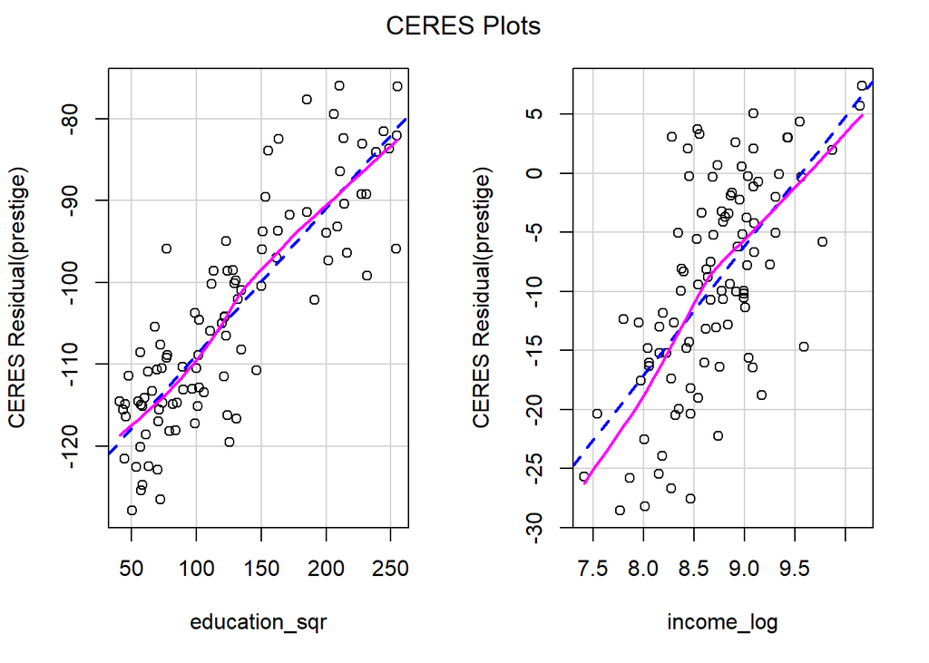

```r
#Linearity
ceresPlots(prestige.lm.3)
```

```r
#linearity statistical assessment
resettest(prestige.lm.3, power=2:3, type="regressor")
```

```
##
##  RESET test
##
## data:  prestige.lm.3
## RESET = 1.1633, df1 = 4, df2 = 91, p-value = 0.3323
```

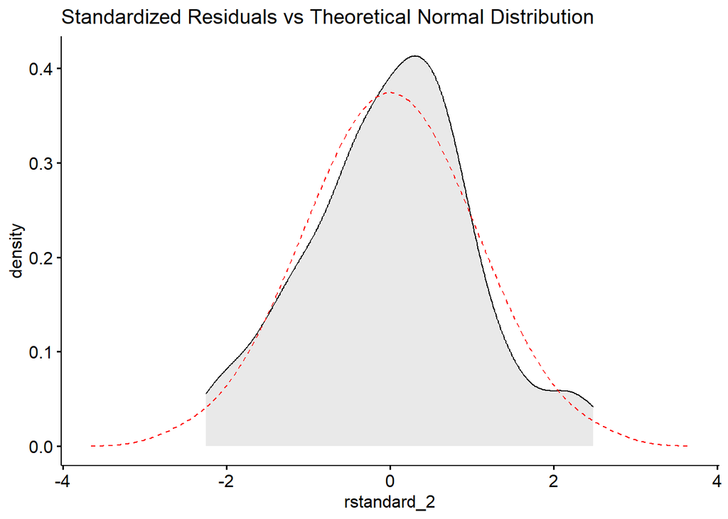

```r
#Normality
ggdensity(Prestige,
          x = "rstandard_2",
          fill = "lightgray",
          title = "Standardized Residuals vs Theoretical Normal Distribution") +
  stat_overlay_normal_density(color = "red",
                              linetype = "dashed")
```

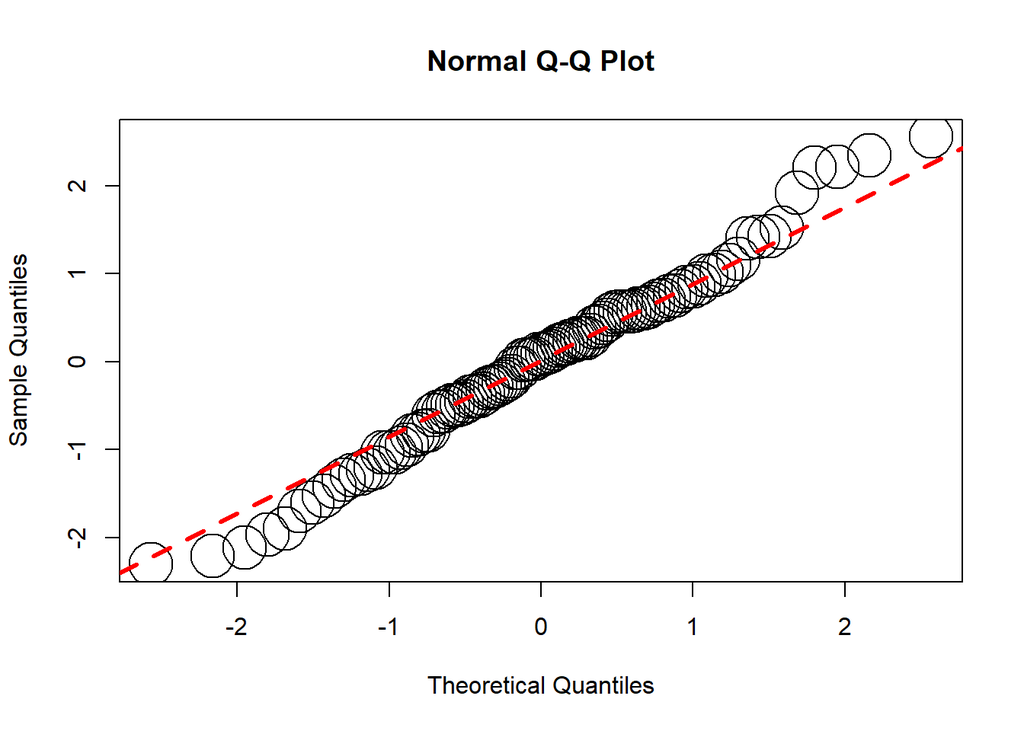

```r
qqnorm(Prestige$rstudent_2, cex = 4)
qqline(Prestige$rstudent_2, lty = 2, col = "red", lwd = 3)
```

```r
shapiro.test(Prestige$rstudent_2)
```

```
##
##  Shapiro-Wilk normality test
##
## data:  Prestige$rstudent_2
## W = 0.9884, p-value = 0.5532
```

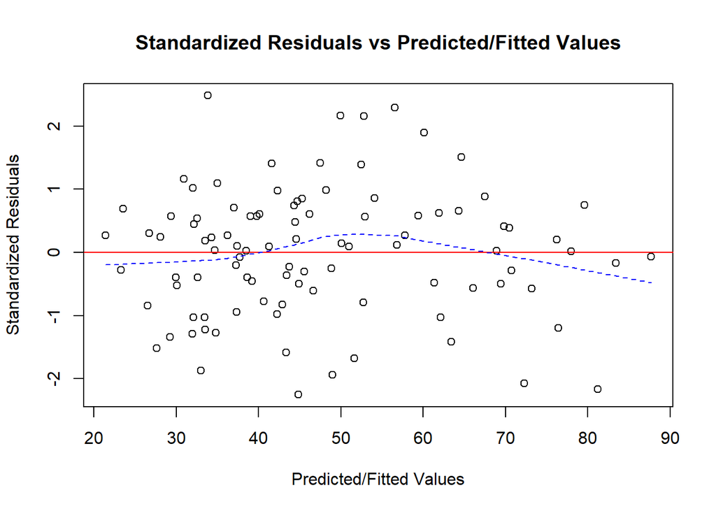

```r
#Homoscedasticity
plot(Prestige$rstandard_2 ~ Prestige$predicted_2,
     main = "Standardized Residuals vs Predicted/Fitted Values",
     xlab = "Predicted/Fitted Values",
     ylab = "Standardized Residuals",
     cex = 1,
     col = "black")
abline(lm(Prestige$rstandard_2 ~ Prestige$predicted_2),
       col = "red")
lines(lowess(Prestige$rstandard_2 ~ Prestige$predicted_2),
      col = "blue", lty = 2)
```

```r
bptest(prestige.lm.3)
```

```
##
##  studentized Breusch-Pagan test
##
## data:  prestige.lm.3
## BP = 6.471, df = 2, p-value = 0.03934
```

From the graph and statistical test, it can be seen that the final model do not violate independence, linearity and normality assumptions. But now this model is violating homoscedasticity assumption.

3. Create a scatterplot of the observed values of `prestige` versus the predicted values of `prestige` from your final model (`plot()`). Fit a regression line to this plot and make an interpretation of the plot.

```r
prestige.lm.3 <- lm(prestige ~ education_sqr + income_log, data = Prestige)
prestige.lm.3 <- summary(prestige.lm.3)$r.squared
prestige.lm.3
```

```
## [1] 0.8408328
```

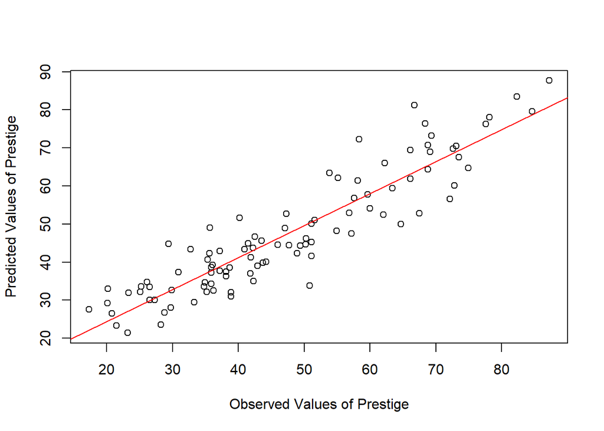

```r
plot(predicted_2 ~ prestige, data = Prestige,
     ylab = "Predicted Values of Prestige",
     xlab = "Observed Values of Prestige")
abline(lm(predicted_2 ~ prestige, data = Prestige),
       col = "red")
mylabel = bquote(italic(R)^2 == .(format(newdf.lm.2d, digits = 2)))
text(3, 8, labels = mylabel)
```

The scatter plot gives us a positive relationship, but the line is aligned with the observed values. There are a few error in observation. The model is good and very well capturing the relationship between the independent and dependent variables.

4. Correlate the observed values of `prestige` versus the predicted values of `prestige` from your final model. Square this value and compare it to the $R^2$ from your final model. Indicate whether those values are the same (they should be).

```r
corr_val=cor(Prestige$predicted_2, Prestige$prestige)
corr_val_square=(corr_val)^2
corr_val_square
```

```
## [1] 0.8408328
```

```r
prestige.lm.3 <- lm(prestige ~ education_sqr + income_log, data = Prestige)
summary(prestige.lm.3)$r.squared
```

```
## [1] 0.8408328
```

Square of correlated value and $R^2$ are the same.

5. Write out the regression equations for the observed and predicted values of the `prestige` outcome variable.

```r
b0 <- coef(prestige.lm.3)[1]
b1 <- coef(prestige.lm.3)[2]
b2 <- coef(prestige.lm.3)[3]

observed_eqn <- paste("Observed Equation:"," ", "prestige = ", round(b0, 2), " + ", round(b1, 2), "* education_sqr" , " + ", round(b2, 2), "* income_log + e", sep = "")

observed_eqn
```

```
## [1] "Observed Equation: prestige = -75.65 + 0.18* education_sqr + 11.54* income_log + e"
```

```r
predicted_eqn <- paste("Predicted Equation:"," ", "prestige = ", round(b0, 2), " + ", round(b1, 2), "* education_sqr" , " + ", round(b2, 2), "* income_log", sep = "")

predicted_eqn
```

```
## [1] "Predicted Equation: prestige = -75.65 + 0.18* education_sqr + 11.54* income_log"
```

6. Create a formatted regression results summary table using one of the methods covered in class. Please also include 95% CIs for each regression slope.

```r
apa.reg.table(prestige.lm.3, table.number = 2)
```

```
##
##
## Table 2
##
## Regression results using prestige as the criterion
##
##
##      Predictor        b          b_95%_CI beta  beta_95%_CI sr2 sr2_95%_CI
##    (Intercept) -75.65** [-102.82, -48.48]
##  education_sqr   0.18**      [0.15, 0.21] 0.66 [0.56, 0.76] .28 [.17, .38]
##     income_log  11.54**     [8.19, 14.88] 0.35 [0.25, 0.45] .08 [.03, .13]
##
##
##
##      r             Fit
##
##  .87**
##  .75**
##            R2 = .841**
##        95% CI[.78,.87]
##
##
## Note. A significant b-weight indicates the beta-weight and semi-partial correlation are also significant.
## b represents unstandardized regression weights. beta indicates the standardized regression weights.
## sr2 represents the semi-partial correlation squared. r represents the zero-order correlation.
## Square brackets are used to enclose the lower and upper limits of a confidence interval.
## * indicates p < .05. ** indicates p < .01.
##
```

### Part IV: Sequential Regression Analysis

Complete the following exercises using the `Health.xlsx` data set, which contains health status information for a random sample of 32 individuals:

[output not shown]

1. Create a scatterplot matrix of these variables (not including `id`).

```r
health<- read_excel("C:\\Users\\Rifatul Islam Himel\\Downloads\\Health.xlsx")
head(health)
```

```
## # A tibble: 6 × 5
##      id   sbp  quet   age   smk
##   <dbl> <dbl> <dbl> <dbl> <dbl>
## 1     1   135  2.88    45     0
## 2     2   122  3.25    41     0
## 3     3   130  3.1     49     0
## 4     4   132  3.77    52     0
## 5     5   131  2.98    54     1
## 6     6   135  2.79    47     1
```

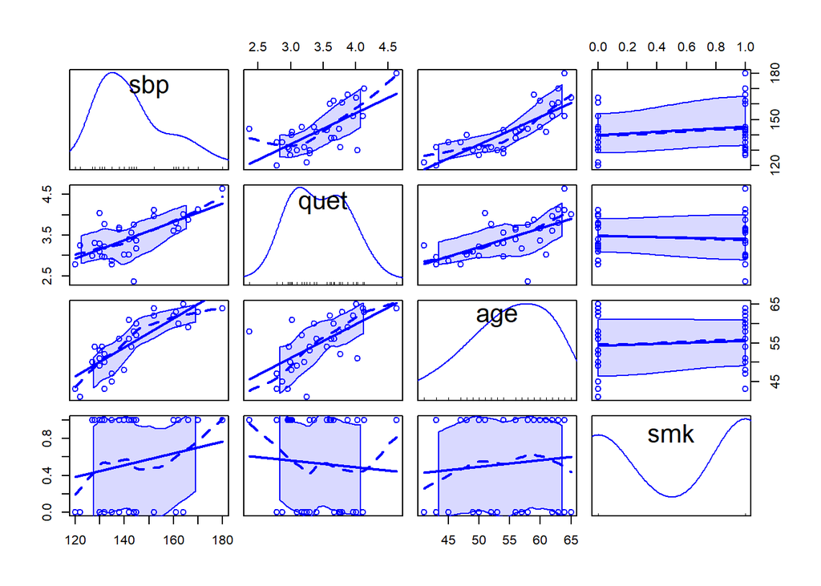

```r
scatterplotMatrix(~sbp + quet + age + smk, data=health)
```

2. Using this data set conduct a **sequential regression analysis** of systolic blood pressure on age, body mass, and smoking status:  
2.1. First step, regress `sbp` on `age` and `quet`.

```r
lm.1.a<- lm(sbp ~ age+quet, data=health)
summ(lm.1.a, confint = TRUE, part.corr = TRUE)
```

```
## MODEL INFO:
## Observations: 32
## Dependent Variable: sbp
## Type: OLS linear regression
##
## MODEL FIT:
## F(2,29) = 35.94, p = 0.00
## R² = 0.71
## Adj. R² = 0.69
##
## Standard errors: OLS
## ------------------------------------------------------------------------------
##                      Est.    2.5%   97.5%   t val.      p   partial.r   part.r
## ----------------- ------- ------- ------- -------- ------ ----------- --------
## (Intercept)         37.24   11.56   62.93     2.97   0.01
## age                  1.45    0.87    2.03     5.15   0.00        0.69     0.51
## quet                 7.54   -0.34   15.41     1.96   0.06        0.34     0.19
## ------------------------------------------------------------------------------
```

2.2. Second step, regress `sbp` on `age`, `quet`, and `smk`.

```r
lm.1.b<- lm(sbp ~ age+quet+smk, data=health)
summ(lm.1.b, confint = TRUE, part.corr = TRUE)
```

```
## MODEL INFO:
## Observations: 32
## Dependent Variable: sbp
## Type: OLS linear regression
##
## MODEL FIT:
## F(3,28) = 25.77, p = 0.00
## R² = 0.73
## Adj. R² = 0.71
##
## Standard errors: OLS
## ------------------------------------------------------------------------------
##                      Est.    2.5%   97.5%   t val.      p   partial.r   part.r
## ----------------- ------- ------- ------- -------- ------ ----------- --------
## (Intercept)         35.73   10.47   60.99     2.90   0.01
## age                  1.37    0.80    1.95     4.90   0.00        0.68     0.48
## quet                 8.52    0.68   16.35     2.23   0.03        0.39     0.22
## smk                  4.40   -1.57   10.37     1.51   0.14        0.27     0.15
## ------------------------------------------------------------------------------
```

2.3. Using a partial *F*-test ($R^2$-change test), indicate whether `smk` accounts for any more variation in `sbp` than `age` and `quet` (Hint: `anova(model1, model2)`).

```r
anova(lm.1.a, lm.1.b)
```

```
## Analysis of Variance Table
##
## Model 1: sbp ~ age + quet
## Model 2: sbp ~ age + quet + smk
##   Res.Df    RSS Df Sum of Sq      F Pr(>F)
## 1     29 1974.2
## 2     28 1825.8  1    148.34 2.2749 0.1427
```

This suggests that the addition of the predictor variable `smk` to the model did not significantly improve the fit, as the p-value is greater than the commonly used threshold of 0.05.

2.4. Using a partial *F*-test ($R^2$-change test), indicate whether `age` has a quadratic relationship with `sbp` (retain `age`, `smk`, and `quet` in this model). (Hint: Compare models with and without `age^2`, and remember to center the `age` variables).

```r
health$age_centered <- health$age - mean(health$age)
lm.1.c <- lm(sbp ~ age_centered + quet + smk, data = health)
lm.1.d <- lm(sbp ~ age_centered + I((age_centered)^2) + quet + smk, data = health)
anova(lm.1.c, lm.1.d)
```

```
## Analysis of Variance Table
##
## Model 1: sbp ~ age_centered + quet + smk
## Model 2: sbp ~ age_centered + I((age_centered)^2) + quet + smk
##   Res.Df    RSS Df Sum of Sq     F   Pr(>F)
## 1     28 1825.8
## 2     27 1365.8  1    459.99 9.093 0.005532 **
## ---
## Signif. codes:  0 '***' 0.001 '**' 0.01 '*' 0.05 '.' 0.1 ' ' 1
```

`age` has a quadratic relationship with `sbp` (retain `age`, `smk`, and `quet` in this model).  
2.5. Report the model $R^2$ for each analysis and the $R^2$-change for each analysis beyond the first model, as well as the results of the *F*-test (including its *p*-value).

```r
summary(lm.1.a)$r.squared
```

```
## [1] 0.7125343
```

```r
summary(lm.1.b)$r.squared
```

```
## [1] 0.7341346
```

```r
print(paste('rsquared change from first to second', "=" , round(summary(lm.1.b)$r.squared, 4)-round(summary(lm.1.a)$r.squared, 4)))
```

```
## [1] "rsquared change from first to second = 0.0216"
```

```r
anova(lm.1.a, lm.1.b)
```

```
## Analysis of Variance Table
##
## Model 1: sbp ~ age + quet
## Model 2: sbp ~ age + quet + smk
##   Res.Df    RSS Df Sum of Sq      F Pr(>F)
## 1     29 1974.2
## 2     28 1825.8  1    148.34 2.2749 0.1427
```

```r
summary(lm.1.c)$r.squared
```

```
## [1] 0.7341346
```

```r
print(paste('rsquared change from second to third', "=" , round(summary(lm.1.c)$r.squared, 4)-round(summary(lm.1.b)$r.squared, 4)))
```

```
## [1] "rsquared change from second to third = 0"
```

```r
anova(lm.1.b, lm.1.c)
```

```
## Analysis of Variance Table
##
## Model 1: sbp ~ age + quet + smk
## Model 2: sbp ~ age_centered + quet + smk
##   Res.Df    RSS Df Sum of Sq F Pr(>F)
## 1     28 1825.8
## 2     28 1825.8  0 1.819e-12
```

```r
summary(lm.1.d)$r.squared
```

```
## [1] 0.8011149
```

```r
print(paste('rsquared change from third to forth', "=" , round(summary(lm.1.d)$r.squared, 4)-round(summary(lm.1.c)$r.squared, 4)))
```

```
## [1] "rsquared change from third to forth = 0.0670000000000001"
```

```r
anova(lm.1.c, lm.1.d)
```

```
## Analysis of Variance Table
##
## Model 1: sbp ~ age_centered + quet + smk
## Model 2: sbp ~ age_centered + I((age_centered)^2) + quet + smk
##   Res.Df    RSS Df Sum of Sq     F   Pr(>F)
## 1     28 1825.8
## 2     27 1365.8  1    459.99 9.093 0.005532 **
## ---
## Signif. codes:  0 '***' 0.001 '**' 0.01 '*' 0.05 '.' 0.1 ' ' 1
```

```r
anova(lm.1.a, lm.1.b, lm.1.c, lm.1.d)
```

```
## Analysis of Variance Table
##
## Model 1: sbp ~ age + quet
## Model 2: sbp ~ age + quet + smk
## Model 3: sbp ~ age_centered + quet + smk
## Model 4: sbp ~ age_centered + I((age_centered)^2) + quet + smk
##   Res.Df    RSS Df Sum of Sq      F   Pr(>F)
## 1     29 1974.2
## 2     28 1825.8  1    148.34 2.9324 0.098283 .
## 3     28 1825.8  0      0.00
## 4     27 1365.8  1    459.99 9.0930 0.005532 **
## ---
## Signif. codes:  0 '***' 0.001 '**' 0.01 '*' 0.05 '.' 0.1 ' ' 1
```

### Part V: Interactions Among Continuous Variables

The data set entitled `Druguse.xlsx` contains responses from 125 adolescents and their self-reported 1) illicit drug use behavior (`druguse`), 2) attitudes toward drug use and health (`attitude`), and 3) peer support (`peersup`). What follows are more formal definitions of the variables:

| Name | Description |
| --- | --- |
| `druguse` | An index score of drug use severity designed for adolescent research (larger numbers indicate more severe drug use problems); outcome variable |
| `attitude` | An ordinal variable ranging from 1 to 5. A score of 1 indicates that the adolescent believes that drugs are NOT harmful at all and a score of 5 indicates that the adolescent believes that drugs are ex… |
| `peersup` | An ordinal variable ranging from 1 to 5. A score of 1 indicates that the adolescent feels no peer support and a score of 5 indicates that the adolescent feels a great deal of peer support; predictor v… |

For the purposes of this assignment, assume that the data for both predictor variables are continuously distributed.

1. Create a scatterplot matrix of these variables.

```r
druguse<- read_excel("C:\\Users\\Rifatul Islam Himel\\Downloads\\Druguse.xlsx")
head(druguse)
```

```
## # A tibble: 6 × 4
##      id druguse attitude peersup
##   <dbl>   <dbl>    <dbl>   <dbl>
## 1     1       3        1       1
## 2     2       4        1       1
## 3     3       5        1       1
## 4     4       6        1       1
## 5     5       7        1       1
## 6     6       3        1       2
```

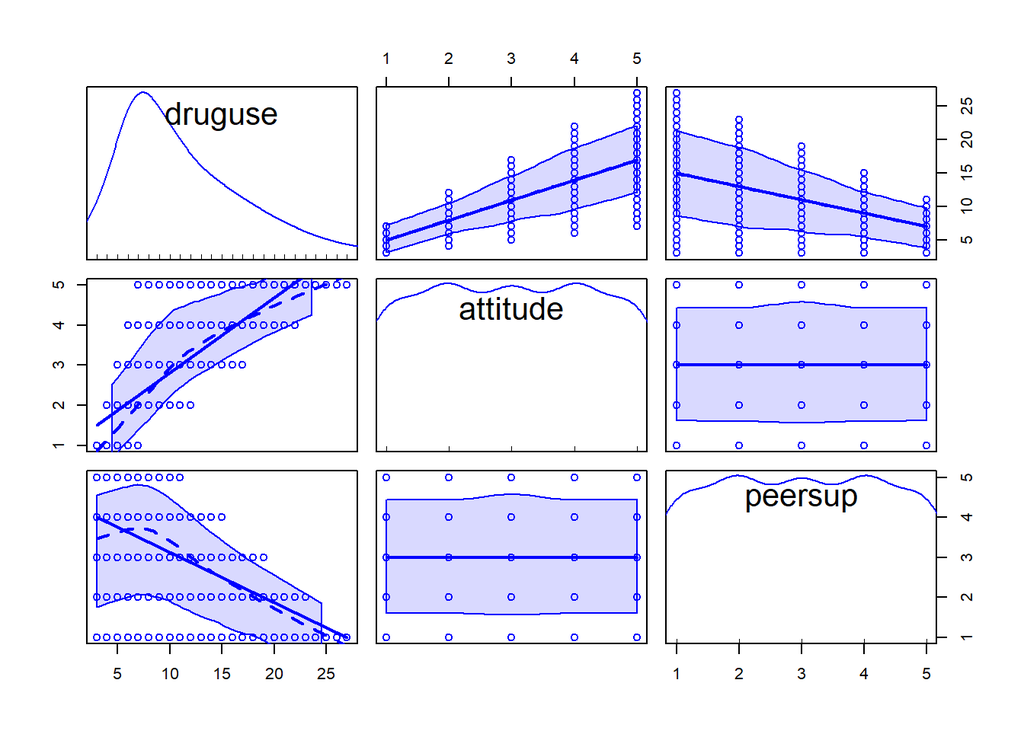

```r
scatterplotMatrix(~druguse + attitude + peersup, data=druguse)
```

2. Test to see if there is a significant interaction between `attitude` and `peersup` using two **sequential regression analyses**: one without and one with the interaction (added last). Determine if the interaction significantly contributes to the model fit ($R^2$) by comparing these nested models. Report the $R^2$ for both models and the $R^2$ difference. Run these models first using the raw data in the data set and then again using centered data.

```r
du.lm.1<- lm(druguse ~ attitude+peersup, data=druguse)
summ(du.lm.1, vifs = TRUE, part.corr = TRUE, digits = 3)
```

```
## MODEL INFO:
## Observations: 125
## Dependent Variable: druguse
## Type: OLS linear regression
##
## MODEL FIT:
## F(2,122) = 264.333, p = 0.000
## R² = 0.813
## Adj. R² = 0.809
##
## Standard errors: OLS
## ---------------------------------------------------------------------------------
##                       Est.    S.E.    t val.       p     VIF   partial.r   part.r
## ----------------- -------- ------- --------- ------- ------- ----------- --------
## (Intercept)          8.000   0.701    11.408   0.000
## attitude             3.000   0.157    19.131   0.000   1.000       0.866    0.750
## peersup             -2.000   0.157   -12.754   0.000   1.000      -0.756   -0.500
## ---------------------------------------------------------------------------------
```

```r
du.lm.2<- lm(druguse ~ attitude+peersup+attitude:peersup, data=druguse)
summ(du.lm.2, vifs = TRUE, part.corr = TRUE, digits = 3)
```

```
## MODEL INFO:
## Observations: 125
## Dependent Variable: druguse
## Type: OLS linear regression
##
## MODEL FIT:
## F(3,121) = 605.000, p = 0.000
## R² = 0.938
## Adj. R² = 0.936
##
## Standard errors: OLS
## ------------------------------------------------------------------------------
##                            Est.    S.E.    t val.       p      VIF   partial.r
## ---------------------- -------- ------- --------- ------- -------- -----------
## (Intercept)              -1.000   0.707    -1.414   0.160
## attitude                  6.000   0.213    28.142   0.000    5.500       0.931
## peersup                   1.000   0.213     4.690   0.000    5.500       0.392
## attitude:peersup         -1.000   0.064   -15.556   0.000   10.000      -0.816
## ------------------------------------------------------------------------------
##
## -------------------------------
##                          part.r
## ---------------------- --------
## (Intercept)
## attitude                  0.640
## peersup                   0.107
## attitude:peersup         -0.354
## -------------------------------
```

```r
anova(du.lm.1, du.lm.2)
```

```
## Analysis of Variance Table
##
## Model 1: druguse ~ attitude + peersup
## Model 2: druguse ~ attitude + peersup + attitude:peersup
##   Res.Df RSS Df Sum of Sq   F    Pr(>F)
## 1    122 750
## 2    121 250  1       500 242 < 2.2e-16 ***
## ---
## Signif. codes:  0 '***' 0.001 '**' 0.01 '*' 0.05 '.' 0.1 ' ' 1
```

```r
print(paste('rsquared for the first model', summary(du.lm.1)$r.squared))
```

```
## [1] "rsquared for the first model 0.8125"
```

```r
print(paste('rsquared for the second model', summary(du.lm.2)$r.squared))
```

```
## [1] "rsquared for the second model 0.9375"
```

```r
print(paste('rsquared change from model1(without interaction) to model2(with interaction)', "=" , round(summary(du.lm.2)$r.squared, 4)-round(summary(du.lm.1)$r.squared, 4)))
```

```
## [1] "rsquared change from model1(without interaction) to model2(with interaction) = 0.125"
```

From the above analysis, we can conclude that the interaction significantly contributes to the model fit.

```r
druguse <-
  druguse %>% mutate(attitude_c = attitude - mean(attitude),
                    peersup_c = peersup - mean(peersup),
                    att_pee_c = attitude_c * peersup_c)


du.lm.3<- lm(druguse ~ attitude_c+peersup_c, data=druguse)
summ(du.lm.3, vifs = TRUE, part.corr = TRUE, digits = 3)
```

[output not shown]

```r
du.lm.4<- lm(druguse ~ attitude_c+peersup_c+att_pee_c, data=druguse)
summ(du.lm.4, vifs = TRUE, part.corr = TRUE, digits = 3)
```

```
## MODEL INFO:
## Observations: 125
## Dependent Variable: druguse
## Type: OLS linear regression
##
## MODEL FIT:
## F(3,121) = 605.000, p = 0.000
## R² = 0.938
## Adj. R² = 0.936
##
## Standard errors: OLS
## ---------------------------------------------------------------------------------
##                       Est.    S.E.    t val.       p     VIF   partial.r   part.r
## ----------------- -------- ------- --------- ------- ------- ----------- --------
## (Intercept)         11.000   0.129    85.560   0.000
## attitude_c           3.000   0.091    33.000   0.000   1.000       0.949    0.750
## peersup_c           -2.000   0.091   -22.000   0.000   1.000      -0.894   -0.500
## att_pee_c           -1.000   0.064   -15.556   0.000   1.000      -0.816   -0.354
## ---------------------------------------------------------------------------------
```

```r
anova(du.lm.3, du.lm.4)
```

```
## Analysis of Variance Table
##
## Model 1: druguse ~ attitude_c + peersup_c
## Model 2: druguse ~ attitude_c + peersup_c + att_pee_c
##   Res.Df RSS Df Sum of Sq   F    Pr(>F)
## 1    122 750
## 2    121 250  1       500 242 < 2.2e-16 ***
## ---
## Signif. codes:  0 '***' 0.001 '**' 0.01 '*' 0.05 '.' 0.1 ' ' 1
```

```r
print(paste('rsquared for the first centered model', summary(du.lm.3)$r.squared))
```

```
## [1] "rsquared for the first centered model 0.8125"
```

```r
print(paste('rsquared for the second centered model', summary(du.lm.4)$r.squared))
```

```
## [1] "rsquared for the second centered model 0.9375"
```

```r
print(paste('rsquared change from centered model1(without interaction) to centered model2(with interaction)', "=" , round(summary(du.lm.4)$r.squared, 4)-round(summary(du.lm.3)$r.squared, 4)))
```

```
## [1] "rsquared change from centered model1(without interaction) to centered model2(with interaction) = 0.125"
```

From the above analysis, we can conclude that the interaction significantly contributes to the model fit. And both centered and not-centered $R^2$ difference is the same.

2.1. Report results of both uncentered and centered analyses by making tables that include the 95% CIs for the slopes as well as the model $R^2$.<br>  
The following tables contains both uncentered and centered analyses (without and with interaction that include the 95% CIs for the slopes as well as the model $R^2$):

```r
summ(du.lm.1, confint = TRUE, part.corr = TRUE)
```

```
## MODEL INFO:
## Observations: 125
## Dependent Variable: druguse
## Type: OLS linear regression
##
## MODEL FIT:
## F(2,122) = 264.33, p = 0.00
## R² = 0.81
## Adj. R² = 0.81
##
## Standard errors: OLS
## ------------------------------------------------------------------------------
##                      Est.    2.5%   97.5%   t val.      p   partial.r   part.r
## ----------------- ------- ------- ------- -------- ------ ----------- --------
## (Intercept)          8.00    6.61    9.39    11.41   0.00
## attitude             3.00    2.69    3.31    19.13   0.00        0.87     0.75
## peersup             -2.00   -2.31   -1.69   -12.75   0.00       -0.76    -0.50
## ------------------------------------------------------------------------------
```

```r
summ(du.lm.3, confint = TRUE, part.corr = TRUE)
```

```
## MODEL INFO:
## Observations: 125
## Dependent Variable: druguse
## Type: OLS linear regression
##
## MODEL FIT:
## F(2,122) = 264.33, p = 0.00
## R² = 0.81
## Adj. R² = 0.81
##
## Standard errors: OLS
## ------------------------------------------------------------------------------
##                      Est.    2.5%   97.5%   t val.      p   partial.r   part.r
## ----------------- ------- ------- ------- -------- ------ ----------- --------
## (Intercept)         11.00   10.56   11.44    49.60   0.00
## attitude_c           3.00    2.69    3.31    19.13   0.00        0.87     0.75
## peersup_c           -2.00   -2.31   -1.69   -12.75   0.00       -0.76    -0.50
## ------------------------------------------------------------------------------
```

```r
summ(du.lm.2, confint = TRUE, part.corr = TRUE)
```

```
## MODEL INFO:
## Observations: 125
## Dependent Variable: druguse
## Type: OLS linear regression
##
## MODEL FIT:
## F(3,121) = 605.00, p = 0.00
## R² = 0.94
## Adj. R² = 0.94
##
## Standard errors: OLS
## -----------------------------------------------------------------------------------
##                           Est.    2.5%   97.5%   t val.      p   partial.r   part.r
## ---------------------- ------- ------- ------- -------- ------ ----------- --------
## (Intercept)              -1.00   -2.40    0.40    -1.41   0.16
## attitude                  6.00    5.58    6.42    28.14   0.00        0.93     0.64
## peersup                   1.00    0.58    1.42     4.69   0.00        0.39     0.11
## attitude:peersup         -1.00   -1.13   -0.87   -15.56   0.00       -0.82    -0.35
## -----------------------------------------------------------------------------------
```

```r
summ(du.lm.4, confint = TRUE, part.corr = TRUE)
```

```
## MODEL INFO:
## Observations: 125
## Dependent Variable: druguse
## Type: OLS linear regression
##
## MODEL FIT:
## F(3,121) = 605.00, p = 0.00
## R² = 0.94
## Adj. R² = 0.94
##
## Standard errors: OLS
## ------------------------------------------------------------------------------
##                      Est.    2.5%   97.5%   t val.      p   partial.r   part.r
## ----------------- ------- ------- ------- -------- ------ ----------- --------
## (Intercept)         11.00   10.75   11.25    85.56   0.00
## attitude_c           3.00    2.82    3.18    33.00   0.00        0.95     0.75
## peersup_c           -2.00   -2.18   -1.82   -22.00   0.00       -0.89    -0.50
## att_pee_c           -1.00   -1.13   -0.87   -15.56   0.00       -0.82    -0.35
## ------------------------------------------------------------------------------
```

2.2. Comment on how the obtained results of uncentered and centered analyses are both similar and different.  
**Answer:** Both uncentered and centered results have similar $R^2$ with and without interaction.

However, slope of uncentered and centered results are very different according to the data provided in 2.1 exercise.

3. Using the results from the **centered** analysis, and using the methods covered in class…  
3.1. Report the simple regression slopes for the relationship between `druguse` and `attitude` at 3 levels or values of `peersup`.  
3.2. Test each simple slope for statistical significance (α <= .05) by examining their confidence intervals.

```r
library(emmeans)

attitude_c_sd_l <- round(mean(druguse$attitude_c) + sd(druguse$attitude_c), 2)
attitude_c_mean <- round(mean(druguse$attitude_c), 2)
attitude_c_sd_h <- round(mean(druguse$attitude_c) - sd(druguse$attitude_c), 2)
attitude_c_sd_l
```

```
## [1] 1.42
```

```r
attitude_c_mean
```

```
## [1] 0
```

```r
attitude_c_sd_h
```

```
## [1] -1.42
```

```r
mylist1 <- list(attitude = c(attitude_c_sd_l, attitude_c_mean, attitude_c_sd_h), peersup = 0)
print(paste("emtrends(du.lm.4, ~ attitude_c + peersup_c, var='peersup_c', at = mylist1) "))
```

```
## [1] "emtrends(du.lm.4, ~ attitude_c + peersup_c, var='peersup_c', at = mylist1) "
```

```r
print(paste(("emtrends(du.lm.4, ~ attitude_c + peersup_c, var='attitude_c', at = mylist1) ")))
```

```
## [1] "emtrends(du.lm.4, ~ attitude_c + peersup_c, var='attitude_c', at = mylist1) "
```

```r
print(paste("attitude_c peersup_c peersup_c.trend     SE  df lower.CL upper.CL
          0         0              -2 0.0909 121    -2.18    -1.82

Confidence level used: 0.95


 attitude_c peersup_c attitude_c.trend     SE  df lower.CL upper.CL
          0         0                3 0.0909 121     2.82     3.18



Confidence level used: 0.95"))
```

[output not shown]

3.3. Compute the expected value of `druguse` for the mean values of `attitude` and `peersup`. 3.4. Compute the predicted value of `druguse` for the median value of `attitude` and three levels of `peersup`. Test to see if those predicted values significantly differ from one another.

```r
mylist4 <- list(attitude_c=0, peersup_c = 0)
mylist4
```

```
## $attitude_c
## [1] 0
##
## $peersup_c
## [1] 0
```

```r
emmeans(du.lm.4, ~ attitude_c + attitude_c * peersup_c, at=mylist4)
```

```
##  attitude_c peersup_c emmean    SE  df lower.CL upper.CL
##           0         0     11 0.129 121     10.7     11.3
##
## Confidence level used: 0.95
```

```r
median(druguse$attitude)
```

```
## [1] 3
```

```r
median(druguse$peersup)
```

```
## [1] 3
```

```r
mylist5 <- list(attitude=3, peersup = 3)
mylist5
```

```
## $attitude
## [1] 3
##
## $peersup
## [1] 3
```

```r
emmeans(du.lm.2, ~ attitude + attitude * peersup, at=mylist5)
```

```
##  attitude peersup emmean    SE  df lower.CL upper.CL
##         3       3     11 0.129 121     10.7     11.3
##
## Confidence level used: 0.95
```

3.5. Create at least one figure that illustrates this interaction.

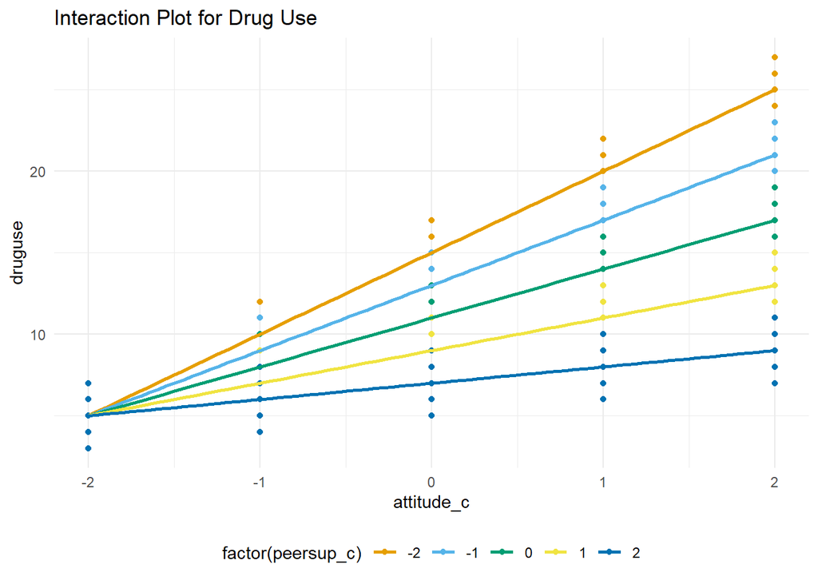

```r
library(ggplot2)


ggplot(druguse, aes(x = attitude_c, y = druguse, color = factor(peersup_c))) +
  geom_point() +
  stat_smooth(method = "lm", se = FALSE) +
  labs(title = "Interaction Plot for Drug Use",
       x = "attitude_c",
       y = "druguse") +
  theme_minimal() +
  theme(legend.position = "bottom") +
  scale_color_manual(values = c("#E69F00", "#56B4E9", "#009E73", "#F0E442", "#0072B2"))
```

3.6. Write a brief interpretation or description of the interaction effect.  
**Answer:**